# Jun Simons - Determinstic Function and Linear Regression

**Learning to use matplotlib with Python**

This is a short example of generating data using a function, and creating a generative model and linear regression from this data.

```python
import numpy as np
import pandas as pd
import scipy.stats as st
import sklearn.linear_model as lm
import matplotlib.pyplot as plt
%matplotlib inline
```

Lets create a **deterministic function** that is not linear to create some values to plot:

```python
def f(x):
    return np.exp(4*x)
```

```python
x_tr = np.linspace(0,2,200)
y_tr = f(x_tr)
```

To make some more random datapoints, we can use the function we already created but add some *Gaussian noise* to the data. Thus we are taking the output of a deterministic and consistent function and generating noise.

```python
x = np.array([0,.1,.2,.5,.8,.9,1,1.1,1.3]) #array of some inputs
y = f(x) + 2*np.random.randn(len(x)) #here we add some noise to output
```

Time to plot the data! We use plt.subplots() which returns a tuple that contains a figure object **(fig)** and an axis object **(ax)**.

A dashed line is plotted according to our x_tr and y_tr data (--k works for making a line dashed).

The graph forms a generative model that includes the distribution of the data itself, letting you know how likley a given example is.

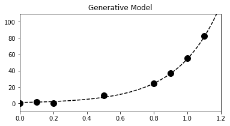

```python
fig, ax = plt.subplots(1,1,figsize=(6,3))
ax.plot(x_tr,y_tr,'--k')
ax.plot(x,y,'ok',ms=10)
ax.set_xlim(0,1.2)
ax.set_ylim(-10,110)
ax.set_title("Generative Model")
```

The dashed line curve shows a generative model created from the output of our function.

## Linear Regression

If we wanted to fit a linear model to this data, we would have to use a linear regression model through scikit-learn. This is quite simple:

```python
linreg = lm.LinearRegression()
linreg.fit(x[:,np.newaxis],y) #train the model with our dataset (x is an array)
y_lr = linreg.predict(x_tr[:,np.newaxis]) #note that x_tr productes y_lr
```

The result can be plotted in the same way, using "y_lr" for the y data when creating the linear regression line.

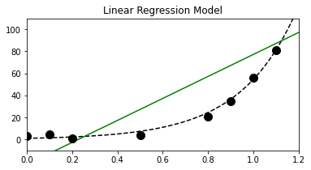

```python
fig, ax = plt.subplots(1,1,figsize=(6,3))
ax.plot(x_tr,y_tr,'--k')
ax.plot(x_tr,y_lr,'g')
ax.plot(x,y,'ok',ms=10)
ax.set_xlim(0,1.2)
ax.set_ylim(-10,110)
ax.set_title("Linear Regression Model")
```